# 03 — Raw Time-Series Explorer (P2)

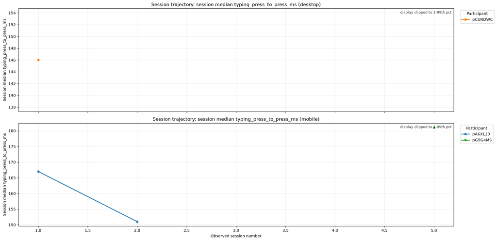

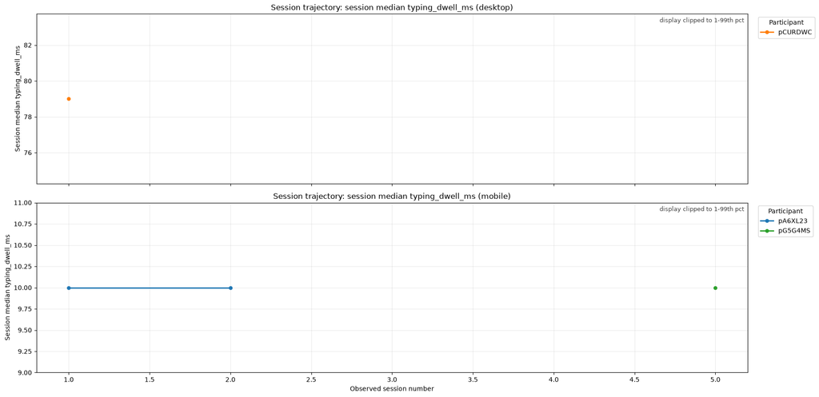

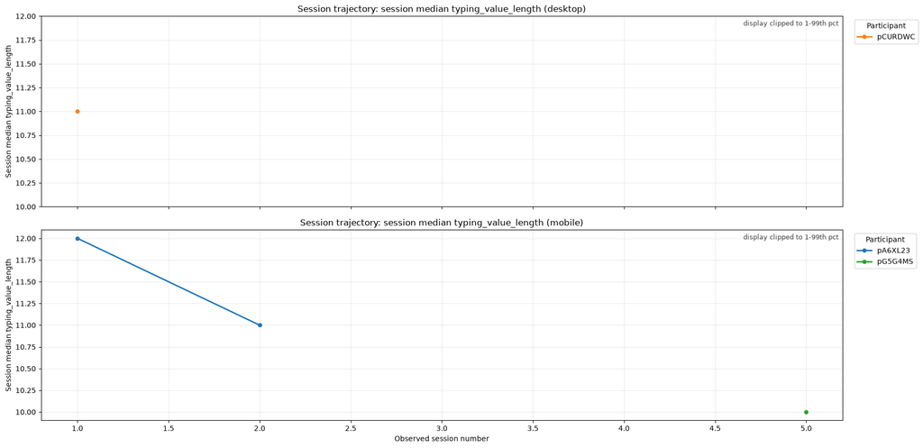

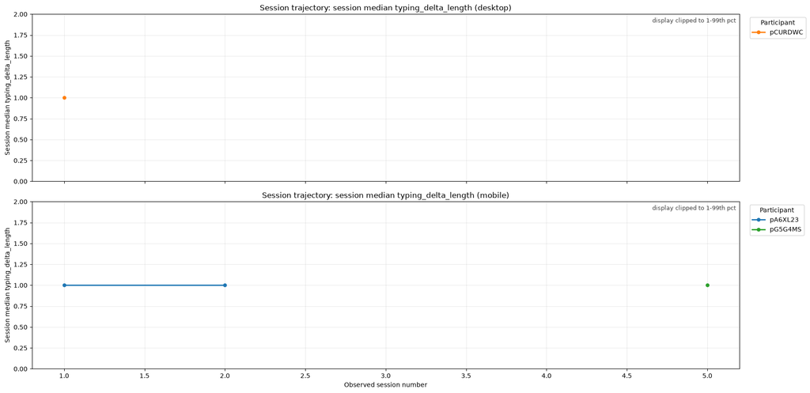

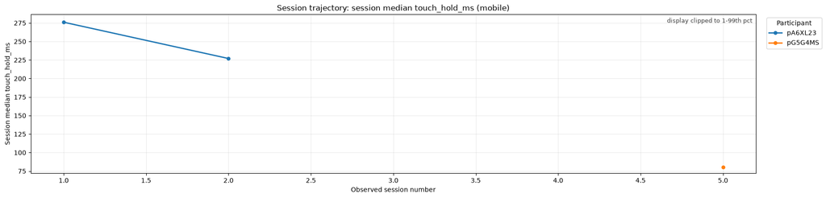

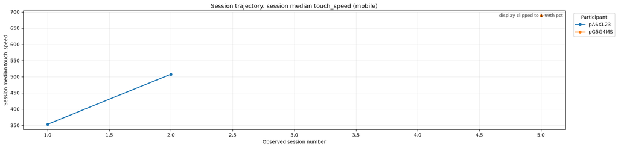

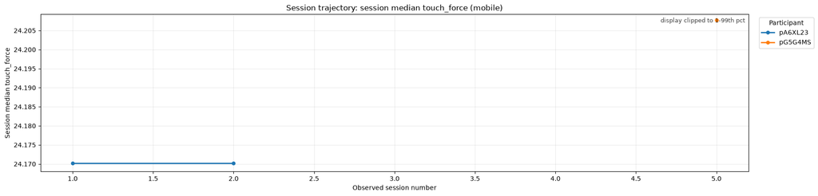

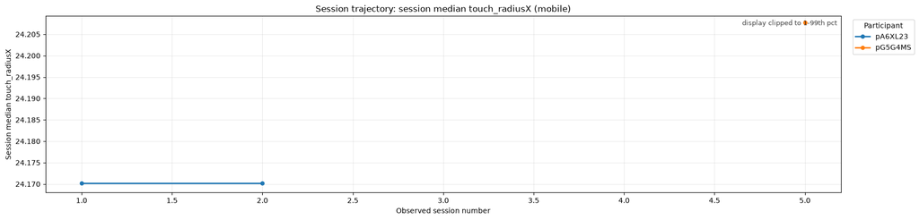

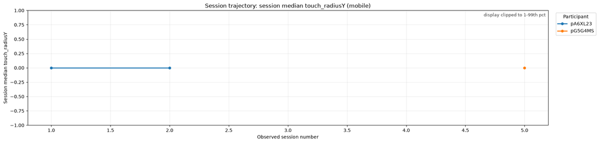

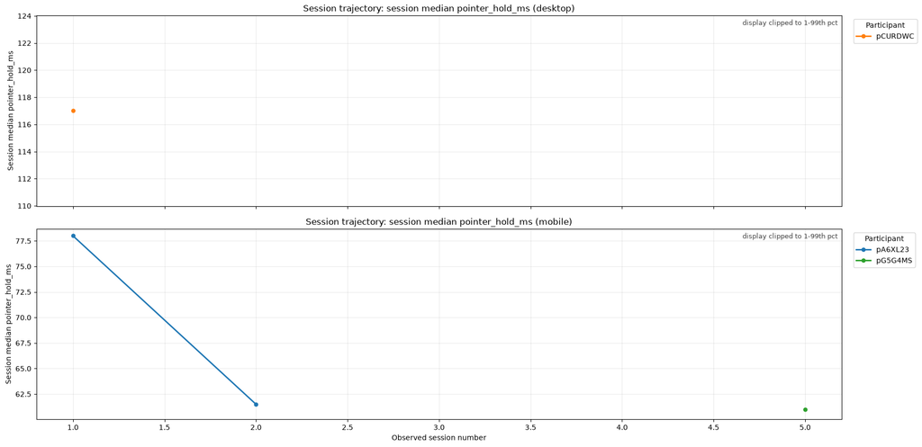

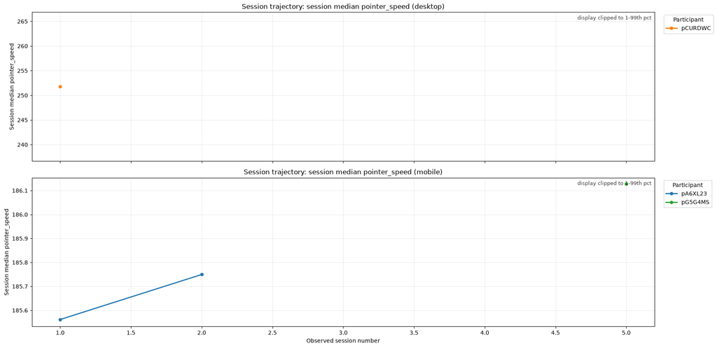

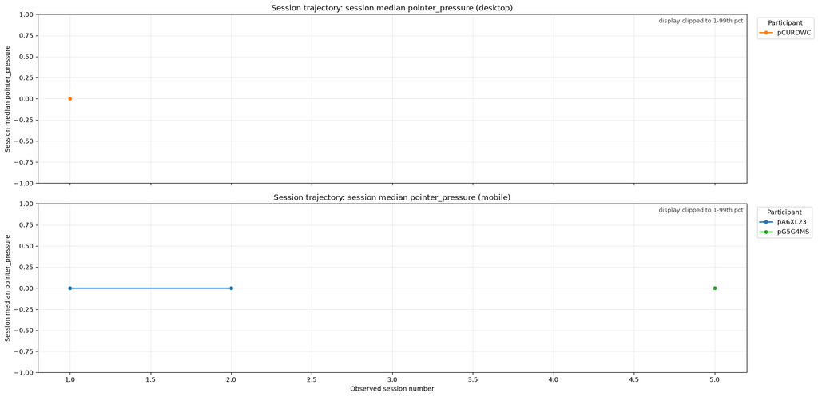

[24 more figures not shown]

```python
for m in metrics_in_scope:
    plot_session_trajectory_by_device_stacked(raw_metric_df, m)
```

## Session-level raw summary table

```python
session_level_summary = (
    filter_time_range(raw_metric_df, TIME_RANGE_S)
    .groupby(['metric', 'participantId', 'sessionId', 'observed_session_number', 'deviceFamily'], dropna=False)
    .agg(session_median=('value', 'median'), session_mean=('value', 'mean'), n_obs=('value', 'size'))
    .reset_index()
    .sort_values(['metric', 'participantId', 'observed_session_number'])
)
session_level_summary
```

|  | metric | participantId | sessionId | observed_session_number | deviceFamily | session_median | session_mean | n_obs |
| --- | --- | --- | --- | --- | --- | --- | --- | --- |
| 0 | approval_swipe_duration | pA6XL23 | 25d4e74f419c4f43a08fb5e0f46847a8 | 1 | mobile | 376.00 | 398.833333 | 6 |
| 1 | approval_swipe_duration | pA6XL23 | 407ab28165b243dfaa35b57079af7ecd | 2 | mobile | 676.00 | 676.000000 | 2 |
| 2 | approval_swipe_duration | pCURDWC | 3e9ec1bb46ba4d8a8c4849d759e8d621 | 1 | desktop | 589.15 | 589.150000 | 2 |
| 3 | approval_swipe_duration | pG5G4MS | b1700a0f31cb4f16ba0a035b7ece41a2 | 5 | mobile | 244.50 | 244.500000 | 2 |
| 4 | approval_swipe_ratio | pA6XL23 | 25d4e74f419c4f43a08fb5e0f46847a8 | 1 | mobile | 1.00 | 1.000000 | 6 |
| ... | ... | ... | ... | ... | ... | ... | ... | ... |
| 120 | typing_press_to_press_ms | pG5G4MS | b1700a0f31cb4f16ba0a035b7ece41a2 | 5 | mobile | 181.00 | 1088.779661 | 118 |
| 121 | typing_value_length | pA6XL23 | 25d4e74f419c4f43a08fb5e0f46847a8 | 1 | mobile | 12.00 | 13.248322 | 149 |
| 122 | typing_value_length | pA6XL23 | 407ab28165b243dfaa35b57079af7ecd | 2 | mobile | 11.00 | 13.593985 | 133 |
| 123 | typing_value_length | pCURDWC | 3e9ec1bb46ba4d8a8c4849d759e8d621 | 1 | desktop | 11.00 | 12.230088 | 113 |
| 124 | typing_value_length | pG5G4MS | b1700a0f31cb4f16ba0a035b7ece41a2 | 5 | mobile | 10.00 | 12.803419 | 117 |

125 rows × 8 columns

## Notes

Use this notebook to decide whether a raw metric shows:

- **within-session temporal structure** — a trend across the session (fatigue, warm-up, task-position effects) rather than a flat, stationary signal
- **between-participant separation through time** — not just pooled shape (that's `02`), but whether the *trajectory itself* looks different per person
- **within-participant, across-session consistency or drift** — the actual tool for behavioural-drift questions; will only become genuinely informative once more participants have multiple sessions

Cross-check anything promising here against `02`'s quantisation table before trusting it — a consistent trajectory can still be a device artifact rather than a person signal.